# Linear Support Vector Classification

```r
library(tidyverse)
library(tidymodels)
library(janitor)
tidymodels_prefer() # Resolves conflicts, prefers tidymodel functions
```

We’re going to load again the breast cancer classification data set:

```r
patients <- read.csv("breast-cancer.csv") %>%
  clean_names() %>%
  mutate(
    class = factor(class),
    bland_chromatin = as.double(bland_chromatin),
    single_epithelial_cell_size = as.double(single_epithelial_cell_size)
  )
```

**Exercise 1.** Split the data into training and test sets. Create a model specification of a linear support vector classifier using `svm_linear`. You will need to install and load the `LiblineaR` package.

**Exercise 2.** Create a recipe to that predicts `class` using only `bland_chromatin` and `single_epithelial_cell_size`. Make sure to normalize the data as the first step in the recipe. Name your recipe `svm_rec`.

**Exercise 3.** Add your recipe and model to a workflow. Fit the workflow to your training set and name it `svm_fit`.

**Exercise 4.** Plot the test set for two variables `bland_chromatin` and `single_epithelial_cell_size`. Color by predicted class. Use the `geom_abline` to plot the decision boundary (the slope and intercept for the decision boundary can be computed using the code below, as long as you named everything the same way I did)

**Exercise 5.** Based on the plot, how did your model do? What drawbacks are there to this linear SVM that you see?

```r
# Calculates the slope and intercept of the linear decision boundary
means <- tidy(prep(svm_rec), 1)$value[1:2]
sds <- tidy(prep(svm_rec), 1)$value[3:4]
coeff <- tidy(svm_fit)$estimate

slope <- -coeff[1] * sds[2] / ( coeff[2] * sds[1] )
intercept <- -coeff[3]*sds[2]/coeff[2] + means[2] + coeff[1]*sds[2]*means[1]/(coeff[2]*sds[1])
```

**Side Note:** If you’re wondering what’s going on in these expressions, remember that we normalized our data, so we created new variables
$$x_{new} = \frac{x -
\bar{x}}{s_x} \qquad \mbox{and} \qquad y_{new} = \frac{y - \bar{y}}{s_y}$$
Subsequently, we found a separating plane in the new variables whose coefficients are stored in the fitted model:
$$a x_{new} + b y_{new} + B = 0$$
Run `tidy(svm_fit)` to see these ($B$ is the `Bias`)! If you plug in the expressions for $x_{new}$ and $y_{new}$ to the plane, and solve for $y$ in terms of $x$, you get a linear expression with the slope and intercept given above.

Here is a less sophisticated way to get a look at the decision boundary: First, I created a grid of points, then used the model to make predictions for each point, then plotted each point, colored by predicted class. The red region is classified as 0 (no cancer) while the blue region is classified as 1 (cancer).

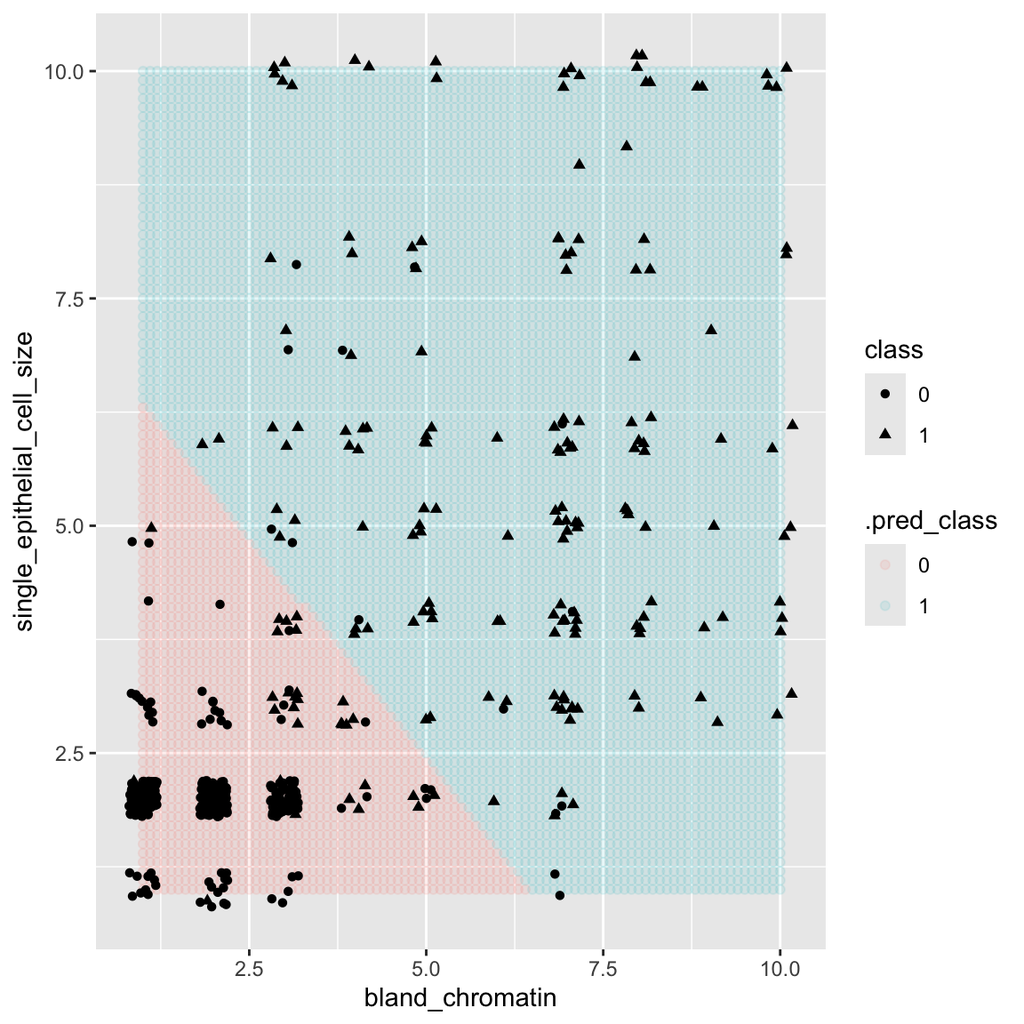

```r
expand_grid(
  bland_chromatin = seq(1, 10, by=.1),
  single_epithelial_cell_size = seq(1, 10, by=.1)
) %>%
  augment(svm_fit, .) %>%
  ggplot(aes(x=bland_chromatin, y=single_epithelial_cell_size)) +
  geom_point(aes( color=.pred_class), alpha=.1) +
  geom_jitter(data=patients_train, aes(shape=class), width=0.2, height=0.2)
```